# Dropped Felony Charges

Jacob Mercer

5/12/2019

```r
lmdc <- lmdc_raw %>%
  mutate(
    BookingNumber = str_trim(BookingNumber, "both"),
    BookingDate = ymd_hms(BookingDate),
    SnapshotDateTime = ymd_hms(SnapshotDateTime),
    RaceDescription = str_trim(RaceDescription, 'both'),
    RaceDescription = if_else(RaceDescription == 'UNKNOWN', 'Other', RaceDescription)
  ) %>%
  filter(BookingDate >= '2014-08-01' & BookingDate <= '2015-08-01')

# drop murder / manslaughter offenders
lmdc_murder_BNs <- lmdc %>%
  filter(str_detect(Charge, "MURDER") | str_detect(Charge, "SLAUGHTER")) %>%
  group_by(BookingNumber) %>%
  summarize()

lmdc <- lmdc %>%
  filter(!BookingNumber %in% lmdc_murder_BNs$BookingNumber)

# find population that has only MISDEMEANORS for all resolved charges

mis_cd <- lmdc %>%
  filter(!is.null(ChargeDisposition) & str_trim(ChargeDisposition, 'both') != '') %>%
  filter(ChargeCategory == 'MISDEMEANOR' | ChargeCategory == 'VIOLATION')

mis_cd_bns <- mis_cd %>%
  group_by(BookingNumber, RaceCode, RaceDescription, CurrentAge, Gender, MaritalStatus, ChargeCategory) %>%
  summarize()

# get the whole charge history for mis_cd_bns

mis_cd_full <- lmdc %>%
  filter(BookingNumber %in% mis_cd_bns$BookingNumber)

# get population of individuals who were booked with felonies but were never charged with felonies

mis_cd_felony_booking_bns <- mis_cd_full %>%
  group_by(BookingNumber) %>%
  filter(SnapshotDateTime == min(SnapshotDateTime)) %>%
  filter(ChargeCategory == 'FELONY') %>%
  distinct(BookingNumber) %>%
  arrange(BookingNumber)

fel_bkng_mis_cd <- lmdc %>%
  filter(BookingNumber %in% mis_cd_felony_booking_bns$BookingNumber)

fel_bkng_mis_cd_pop <- fel_bkng_mis_cd %>%
  group_by(BookingNumber, RaceCode, RaceDescription) %>%
  summarize(ChargeCount = n()) %>%
  filter(!duplicated(BookingNumber)) %>%
  arrange(BookingNumber)

# be able to compare against total lmdc pop

lmdc_pop <- lmdc %>%
  group_by(BookingNumber, RaceCode, RaceDescription) %>%
  summarize(ChargeCount = n()) %>%
  filter(!duplicated(BookingNumber)) %>%
  arrange(BookingNumber)

# get top N felonies dropped for white vs non-white
# filter out to look at just the charges for initial booking (since we know the end state is no felonies)

fb_mc_booking_BN_time <- fel_bkng_mis_cd %>%
  group_by(BookingNumber, SnapshotDateTime) %>%
  summarize() %>%
  filter(SnapshotDateTime == min(SnapshotDateTime)) %>%
  mutate(
    combo = str_c(BookingNumber, SnapshotDateTime, sep = '_')
  )

charges_at_booking <- fel_bkng_mis_cd %>%
  filter(str_c(BookingNumber, SnapshotDateTime, sep = '_') %in% fb_mc_booking_BN_time$combo)

top_n_w_f <- charges_at_booking %>%
  filter(RaceCode == 'W') %>%
  filter(ChargeCategory == "FELONY") %>%
  group_by(Charge) %>%
  summarize(Count = n()) %>%
  top_n(20, Count) %>%
  arrange(desc(Count))

colnames(top_n_w_f) <- c('Charges : White', 'Count : White')

top_n_non_w_f <- charges_at_booking %>%
  filter(RaceCode != 'W') %>%
  filter(ChargeCategory == "FELONY") %>%
  group_by(Charge) %>%
  summarize(Count = n()) %>%
  top_n(20, Count) %>%
  arrange(desc(Count))

colnames(top_n_non_w_f) <- c('Charge : Non-White', 'Count : Non-White')

top_n_chart <- cbind(top_n_w_f, top_n_non_w_f)
```

When individuals are booked they are sometimes charged with crimes that are later dropped. This analysis examines the population of individuals who were charged with felonies but, by the time all charges were resolved, these individuals were only charged with misdemeanors. That is, the population of individuals who were charged with felonies that were subsequently dropped.

The population examined exists between the 12 month period of August 2014 through July 2015. Please see NOTE at the end for more information about the methodology.

This graphic compares the population of individuals with felonies that get dropped against the entire population of individuals booked:

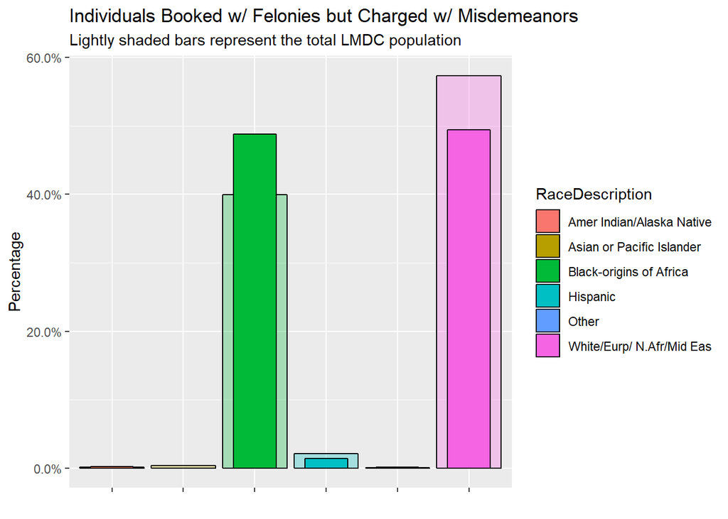

```r
ggplot() +
  geom_bar(data = lmdc_pop,
           aes(x = RaceDescription,
               y = (..count..)/sum(..count..),
               fill = RaceDescription),
           color = 'black',
           alpha = .3) +
  geom_bar(data = fel_bkng_mis_cd_pop,
           aes(x = RaceDescription,
               y = (..count..)/sum(..count..),
               fill = RaceDescription),
           color = 'black',
           width = .6) +
scale_y_continuous(labels=scales::percent) +
  ggtitle("Individuals Booked w/ Felonies but Charged w/ Misdemeanors",
          subtitle = 'Lightly shaded bars represent the total LMDC population') +
  ylab("Percentage") +
  xlab('') +
  theme(axis.text.x = element_blank())
```